# Estudio sobre las tandas de penales realizadas en torneos internacionales de la división masculina de futbol

03 Mayo, 2023

# Introducción

## Importancia y Justificación

El deporte rey, el fútbol, es caracterizado por el trabajo en equipo y la habilidad de los jugadores. Entre tantos momentos emocionantes, el que más destaca es uno que parece casi sacado de un casino o un juego de azar: los penales. En estos se enfrentan uno a uno los pateadores y guardametas más hábiles de su país. Sin embargo, incluso para ellos, los penales aún parecen ser cuestión de sentir el momento y adivinar. Sería sencillo continuar con este pensamiento y asumir la mística de los penales como una obra del azar; pero la estadística y la probabilidad pueden esclarecer esta situación para los involucrados.

[figure not shown]

# Objetivos

## Objetivo Principal

1. Precisar mediante un análisis estadístico si existe o no matemáticamente uno o mas factores externos que influyan en tener mayor probabilidad de acertar un penal.

## Objetivos Específicos

1. Analizar rondas de penales de copas importantes y encontrar factores y/o situaciones favorables semejantes en cada una de ellas.
2. Evaluar las condiciones físicas tanto de arqueros y jugadores para evidenciar el rendimiento que estos o sus compañeros podrían llegar a tener en una futura ronda de penales.

# Factibilidad

La siguiente tabla detalla las características y objetivos de cada entrega para cumplir con sus requerimientos. La fecha de lanzamiento de la tarea, el tiempo de trabajo para completar la tarea y la fecha de entrega de cada artículo se especifican en detalle.

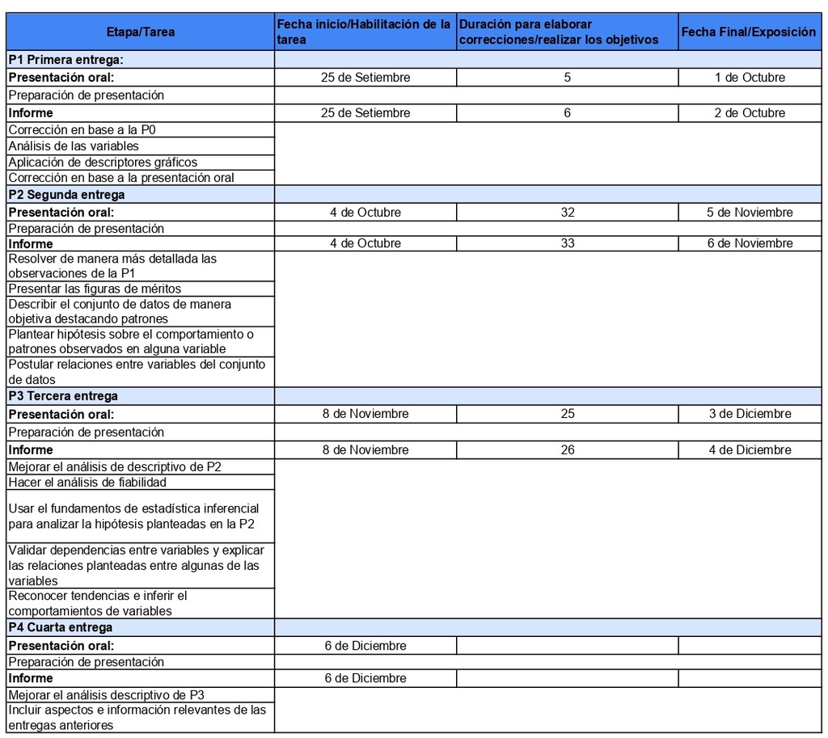

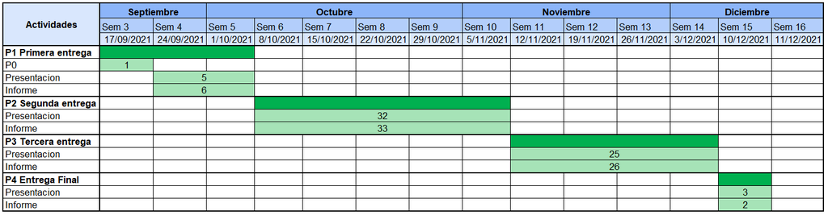

# Marco Teórico

El tiro de penal se creó en 1981 para evitar las situaciones en las que los jugadores impedían un gol más que probable de sus rivales y no recibir más sanción que una falta. Para definir un ganador cada equipo escoge a sus 5 mejores pateadores para un enfrentamiento individual con el guardameta contrario. Este enfrentamiento de los penaltis es acreditado al guardameta y empresario Willian McCrum en Irlanda del Norte. La Irish Football Association (asociación de Irlanda) presentó esta idea a la International Football Association Board que, tras mucho debate, fue aprobado el 2 de junio de 1981 con la finalidad de obtener un ganador tanto como un perdedor.

Por años, tanto espectadores como los propios futbolistas han puesto en duda si es que los penales se rigen por mera cuestión del destino o si existen algunos parámetros que se deben seguir. Es por ello que , hasta la fecha, existen muchos “estudios” que afirman múltiples factores que determinan el acierto o no de cada penal.

## Población Objetivo

Todos las tandas de penales pateados en las copas mundiales, Eurocopas y Copas América desde el 2014 al 2021

## Unidad muestral

Haremos un muestreo aleatorio simple del total de tanda de penales diputadas en cada copa dentro del rango de años seleccionados

# Variables y su definición

## Numéricas (10)

### Continuas (8)

| **Pregunta** | **Variable** | **Restricciones** |
| --- | --- | --- |
| ¿Cuál es el ángulo con el que patea el penal el jugador con respecto al ras de piso? | Angulo | Entre 0° a 90° (P2) |
| ¿En qué punto horizontal respecto al palo izquierdo pasó la pelota? | Coordenada_X | Entre 0 a 7.32 m.(P2) |
| ¿En qué punto vertical respecto al ras del piso pasó la pelota? | Coordenada_Y | Entre 0 a 2.44 m. (P2) |
| ¿Cuál es la estatura del jugador? | Estatura_J | Entre 1.6 a 2.1 m. |
| ¿Cuál es la estatura del arquero? | Estatura_A | Entre 1.6 a 2.1 m. |
| ¿Cuál es el peso del arquero? | Peso_A | Entre 75 a 100 kg |
| ¿Cuánto tiempo jugó el jugador antes de patear el penal? | Tiempo_J | Entre 0 a 135 min.(P2) |
| ¿Cuánto tiempo se demoró el jugador en patear luego del pitido? | Tiempo_prev | Entre 0.5 a 15 seg.(P2) |

- (P2) Consideramos que estas variables serán mejor planteadas en la segunda entrega.

### Discretas (2)

| **Pregunta** | **Variable** | **Restricciones** |
| --- | --- | --- |
| ¿Cuál es la edad del jugador? | Edad_J | Entre 17 a 40 años |
| ¿Cuál es la edad del arquero? | Edad_P | Entre 17 a 40 años |

## Categóricas (15)

### Ordinales (2)

| **Pregunta** | **Variable** | **Restricciones** |
| --- | --- | --- |
| ¿Cuál es el número de orden en el que le tocó patear el penal al jugador? | N_Lanzamiento | 1 a 48 |
| ¿En qué año se jugo la copa? | año_c | años de la copa |

### Nominales (13)

| **Pregunta** | **Variable** | **Restricciones** |
| --- | --- | --- |
| ¿Cuál es nombre del jugador? | Nombre_J | Nombre del Jugador |
| ¿Cuál es apellido del jugador? | Apellido_J | Apellido del Jugador |
| ¿Cuál es nombre del arquero? | Nombre_A | Nombre del Arquero |
| ¿Cuál es apellido del arquero? | Apellido_A | Apellido del Arquero |
| ¿Qué país están en ronda de penales? | Partido | El nombre de ambos paises que están en penales |
| ¿Cuál equipo va a patear? | Equipo_P | País del Jugador/Arquero |
| ¿Cuál equipo va a tapar? | Equipo_T | País del Jugador/Arquero |
| ¿Cuál es la copa que se juega? | copa | Eurocopa, Copa América o Mundial |
| ¿Con qué pierna tiró el penal el jugador? | Pierna | Izquierda o Derecha |
| ¿El arquero provocó al jugador? | Provocacion | Sí o no (P2) |
| ¿Cuál fue el resultado del penal? | Resultado_P | Gol, Tapado, Palo o Fuera |
| ¿Hubo mayor proporción de hinchas del jugador en la grada posterior al arco? | hinchas_J | Sí o no (P2) |
| ¿Cual es la posición del jugador que pateo el penal? | Posición | Delantero, Mediocampista o defensa |

Nota: (P2) Consideramos que estas variables serán mejor planteadas en la segunda entrega.

# Base de datos

Para leer un archivo de datos de extensión .csv

```r
DF_A <- read_csv("BasedeDatos_Arquero.csv")
DF_J <- read_csv("BasedeDatos_Jugador.csv")
names(DF_A)
```

```
##  [1] "Copa"          "Año_C"         "Partido"       "N_Lanzamiento"
##  [5] "Nombre_A"      "Apellido_A"    "Estatura_A"    "Edad_A"
##  [9] "Peso_A"        "P.Equipo_T"    "Resultado_P"
```

```r
names(DF_J)
```

```
##  [1] "Copa"          "Año_C"         "Partido"       "N_Lanzamiento"
##  [5] "Nombre_J"      "Apellido_J"    "Posicion"      "Estatura_J"
##  [9] "Edad_J"        "Tiempo_J"      "Tiempo_Prev"   "P.Equipo_P"
## [13] "Pierna"        "Hinchas_J"     "Angulo H"      "Angulo V"
## [17] "Coordenada_X"  "Coordenada_Y"  "Resultado_P"
```

# Descriptores Numéricos

## Variables cuantitativas

Se presenta una tabla con todas las variables numéricas y sus respectivos resultados a diferentes medidas.

| **Variable** | **Media** | **Moda** | **Mediana** | **IQR** | **Mínimo** | **Máximo** | **Rango** | **Coeficiente de Variación** | **Varianza** | **Desviación Estándar** |
| --- | --- | --- | --- | --- | --- | --- | --- | --- | --- | --- |
| Estatura_J | 179.78 | 178 | 180 | 10 | 163 | 194 | 31 | 3.59 | 41.56 | 6.45 |
| Tiempo_J | 91.16 | 130 | 99 | 74 | 1 | 133 | 132 | 45.47 | 1718.5 | 41.45 |
| Tiempo_Prev | 4.38 | 4 | 4 | 2 | 2 | 12 | 10 | 39.33 | 2.97 | 1.72 |
| Edad_J | 27.87 | 27 29 | 28 | 5 | 20 | 39 | 19 | 12.84 | 12.8 | 3.58 |
| Estatura_A | 188.68 | 185 | 190 | 7 | 183 | 195 | 12 | 1.8 | 11.5 | 3.39 |
| Peso_A | 83.17 | 79 | 82 | 9 | 74 | 93 | 19 | 6.83 | 32.27 | 5.68 |
| Edad_A | 30.13 | 27 | 30 | 5 | 24 | 38 | 14 | 11.91 | 12.88 | 3.59 |
| Coordenada_X | 3.39 | 1.18 | 2.96 | 4.23 | -1.23 | 7.74 | 8.97 | 68.68 | 5.43 | 2.33 |
| Coordenada_Y | 1.05 | 0.1 | 0.98 | 1.19 | 0.03 | 3.88 | 3.85 | 80.19 | 0.7 | 0.84 |

### Análisis de las variables

[output not shown]

### Descriptores gráficos

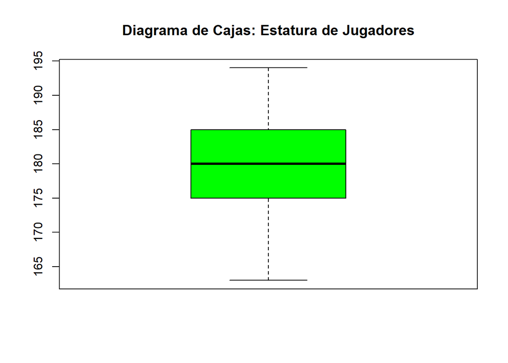

```r
boxplot(DF_J$Estatura_J, horizontal = F, col = "green", main = "Diagrama de Cajas: Estatura de Jugadores")# Diagrama vertical respecto a las Estaturas de los jugadores
```

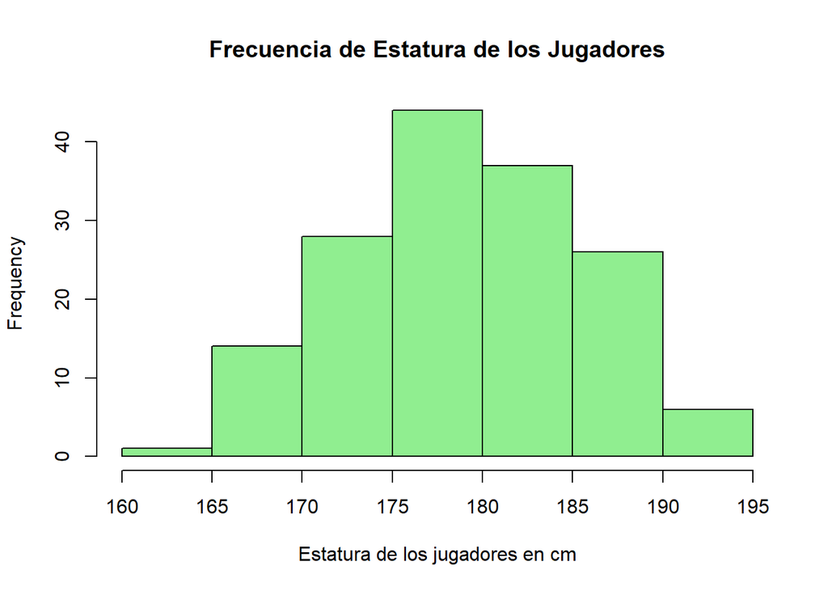

```r
hist(DF_J$Estatura_J, col = "lightgreen", main = "Frecuencia de Estatura de los Jugadores",xlab = "Estatura de los jugadores en cm")
```

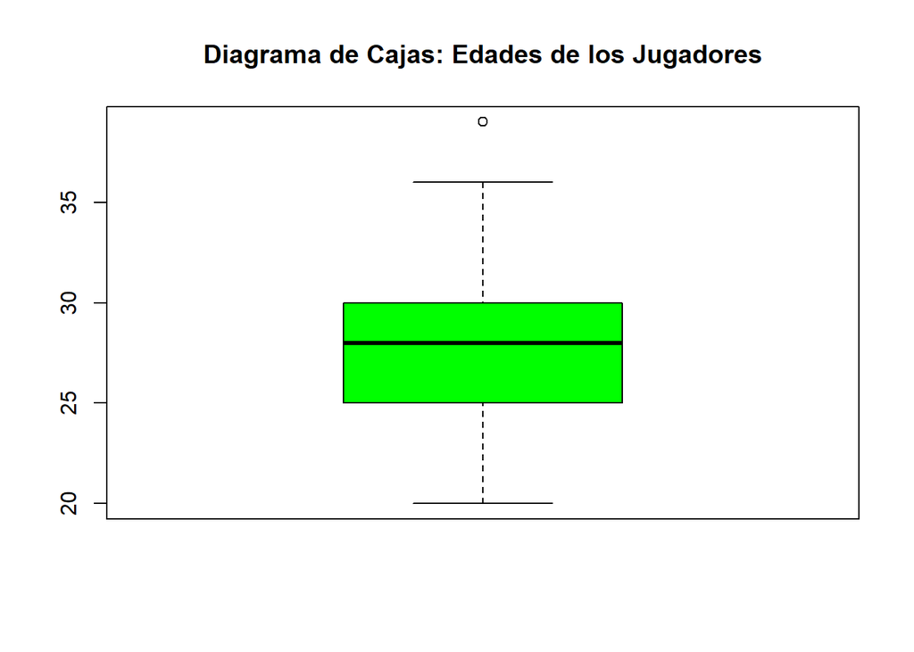

```r
boxplot(DF_J$Edad_J, horizontal = F, col = "green", main = "Diagrama de Cajas: Edades de los Jugadores")
```

*Comentario:* Se puede apreciar que este gráfico que existe un dato atípico, donde un jugador sobrepasa los 35 años. Además, vemos que existe mayor concentración entre el segundo y tercer cuartil que entre el primero y segundo.

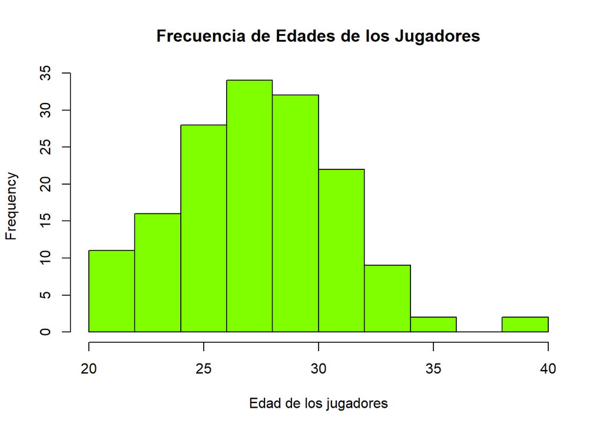

```r
hist(DF_J$Edad_J, col = "chartreuse1", main = "Frecuencia de Edades de los Jugadores",xlab = "Edad de los jugadores")
```

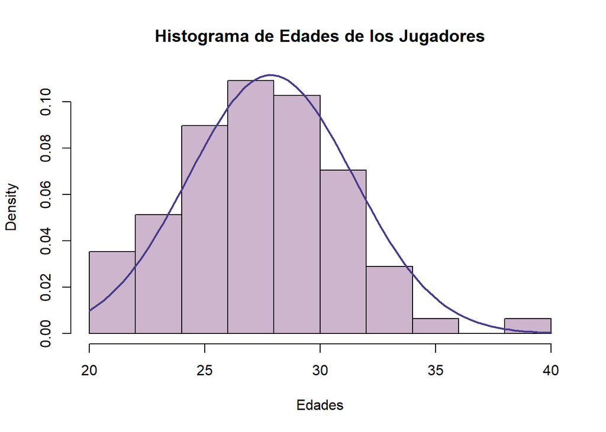

```r
hist(DF_J$Edad_J,main="Histograma de Edades de los Jugadores", col="thistle3", xlab = "Edades", freq = FALSE)
curve(dnorm(x, mean(DF_J$Edad_J), sd = sd(DF_J$Edad_J)),
      col = "slateblue4",
      lwd= 2,
      las = 1, # Etiquetas alineadas horizontalmente
      ann = FALSE, # Sin títulos en los ejes
      xaxp = c(-15, 15, 5),  # Marcas del eje x
      ylim = c(0,0.00020), # Límites del eje
      yaxs = "i", add=TRUE) # Estilo del eje y, ajustado a los límites
```

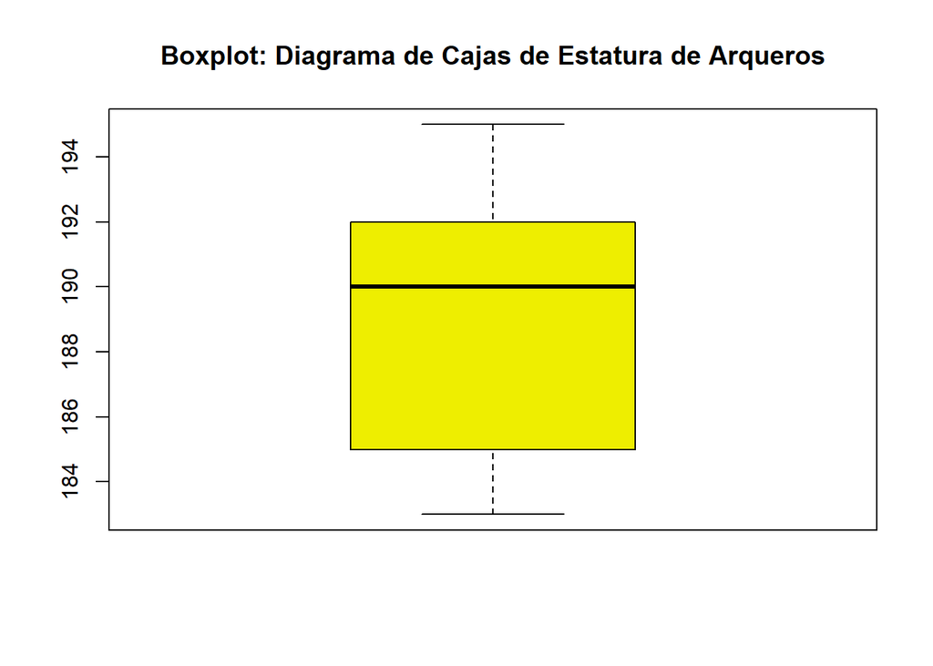

```r
boxplot(DF_A$Estatura_A, horizontal = F, col = "yellow2", main = "Boxplot: Diagrama de Cajas de Estatura de Arqueros")
```

*Comentario:* Podemos observar que desde el primer cuartil hasta el segundo cuartil (la mediana) existe una mayor dispersión de observaciones.

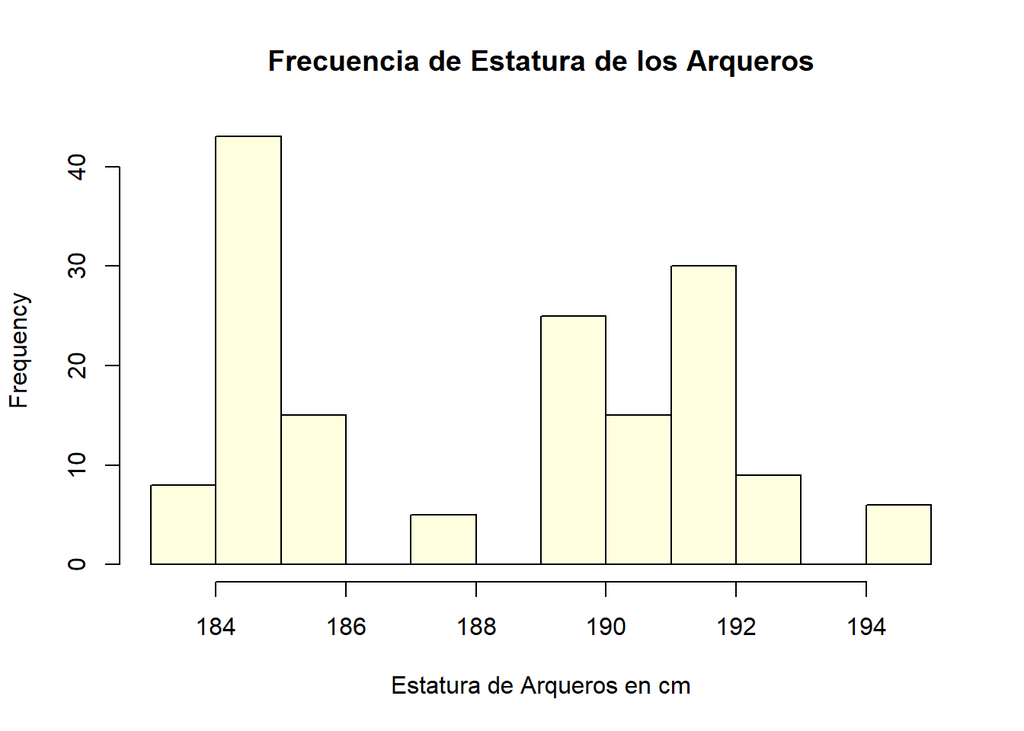

```r
hist(DF_A$Estatura_A, col = "lightyellow", main = "Frecuencia de Estatura de los Arqueros",xlab = "Estatura de Arqueros en cm")
```

*Comentario:* Con este gráfico complementamos la idea presentada en el anterior diagrama de que existe una gran dispersión entre el primer cuartil y segundo cuartil. Además, existe una gran cantidad de arqueros que miden entre 1.84 y 1.85 metros.

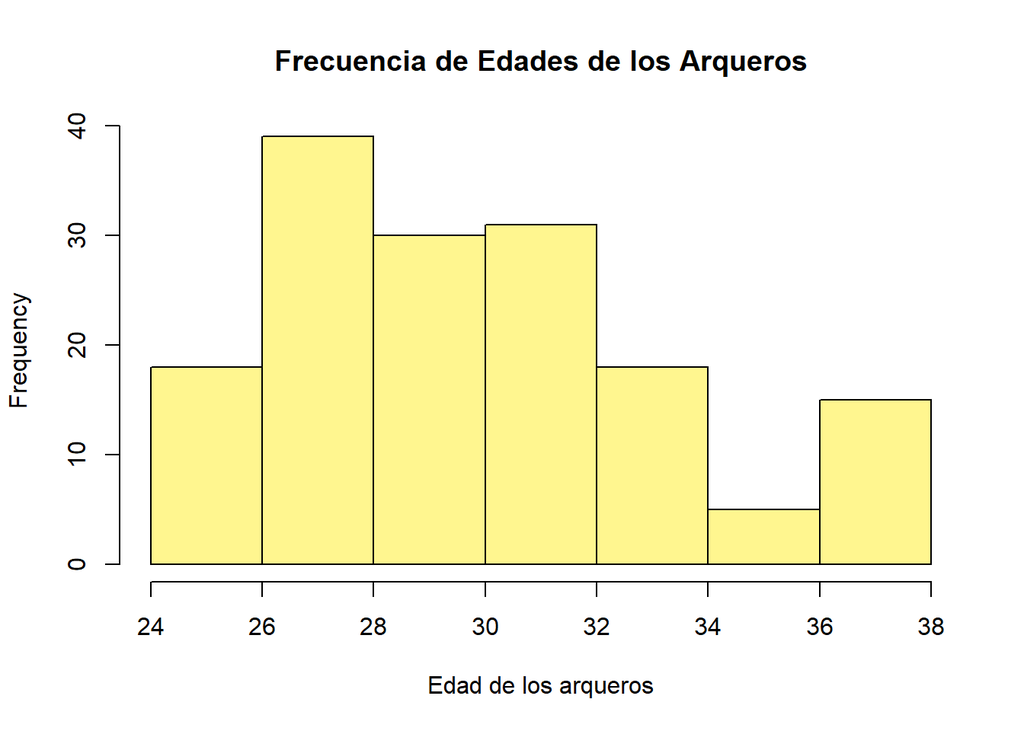

```r
hist(DF_A$Edad_A, col = "khaki1", main = "Frecuencia de Edades de los Arqueros",xlab = "Edad de los arqueros")
```

*Comentario:* Se puede apreciar un histograma multimodal en el cual la mayor concentración está entre 26 y 28 años.

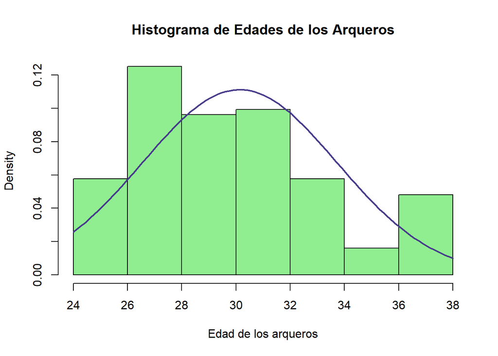

```r
hist(DF_A$Edad_A,main="Histograma de Edades de los Arqueros", col="lightgreen", xlab = "Edad de los arqueros", freq = FALSE)
curve(dnorm(x, mean(DF_A$Edad_A), sd = sd(DF_A$Edad_A)),
      col = "slateblue4",
      lwd= 2,
      las = 1, # Etiquetas alineadas horizontalmente
      ann = FALSE, # Sin títulos en los ejes
      xaxp = c(-15, 15, 5),  # Marcas del eje x
      ylim = c(0,0.00020), # Límites del eje
      yaxs = "i", add=TRUE) # Estilo del eje y, ajustado a los límites
```

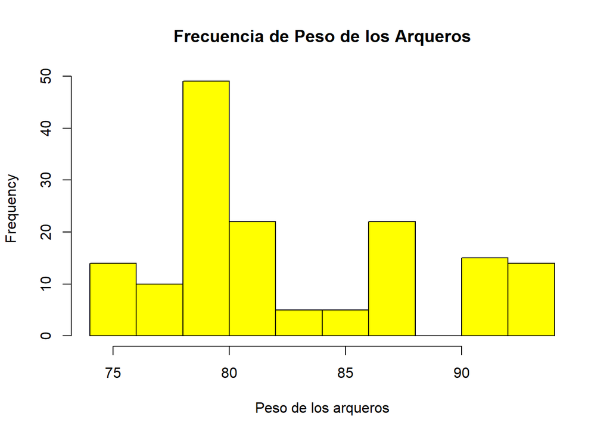

```r
hist(DF_A$Peso_A, col = "yellow", main = "Frecuencia de Peso de los Arqueros",xlab = "Peso de los arqueros")
```

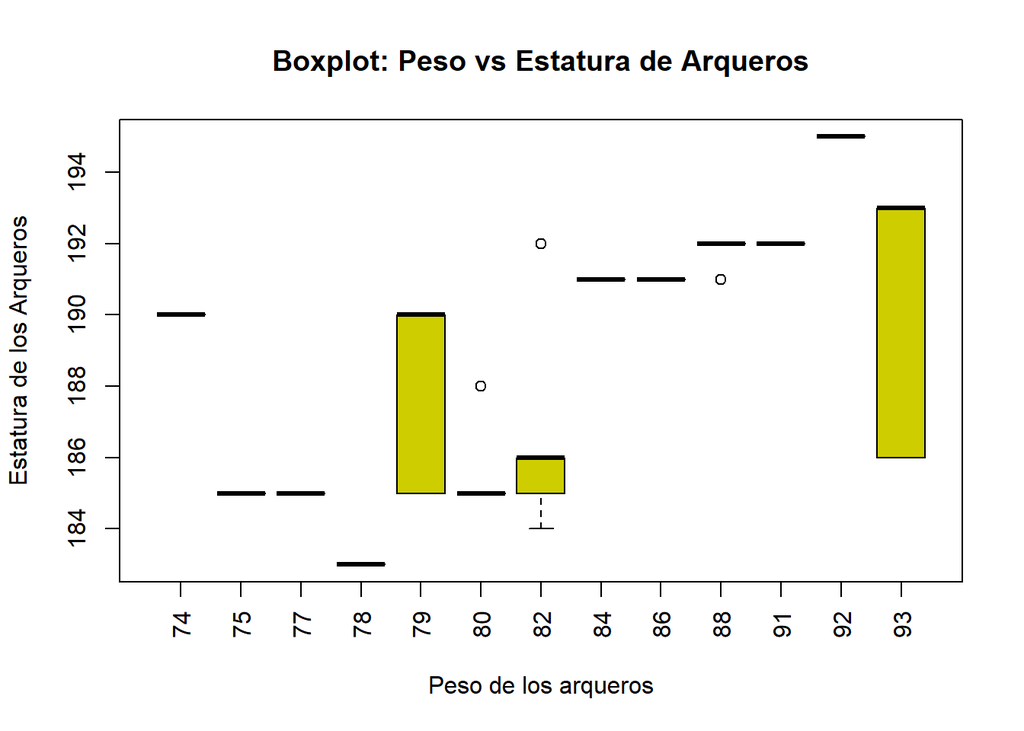

```r
boxplot(DF_A$Estatura_A ~ DF_A$Peso_A, las = 3, cex.ais =0.6, col = "yellow3", main="Boxplot: Peso vs Estatura de Arqueros",xlab = "Peso de los arqueros", ylab = "Estatura de los Arqueros") # categorización de la variable Peso
```

## Variables cualitativas

### Análisis de las variables cualitativas

[output not shown]

### Descriptores Gráficos

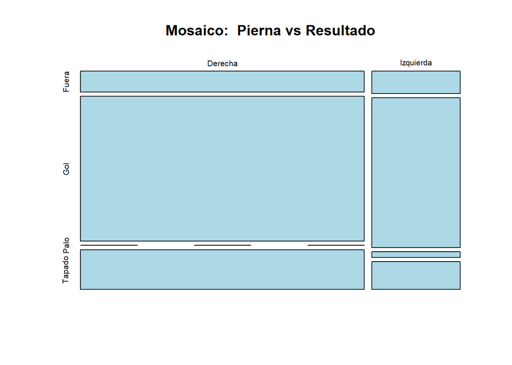

```r
#Pierna con la patea
mosaicplot(table(DF_J$Pierna,DF_J$Resultado_P),col = "lightblue", main="Mosaico:  Pierna vs Resultado")
```

*Comentario:* Podemos concluir que la mayoría de los jugadores patea con la pierna derecha. Sin embargo, por mínima diferencia, la efectiva mayor radica en aquellos que patean con la izquierda.

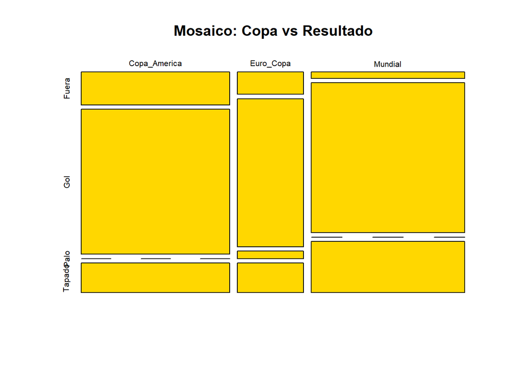

```r
#Copas
mosaicplot(table(DF_A$Copa,DF_A$Resultado_P),col = "gold1", main="Mosaico: Copa vs Resultado")
```

*Comentario:* El mayor porcentaje de tiros fuera del arco se encuentra en las Copas Américas. Además, los arqueros que más tapan se encuentran en los mundiales.

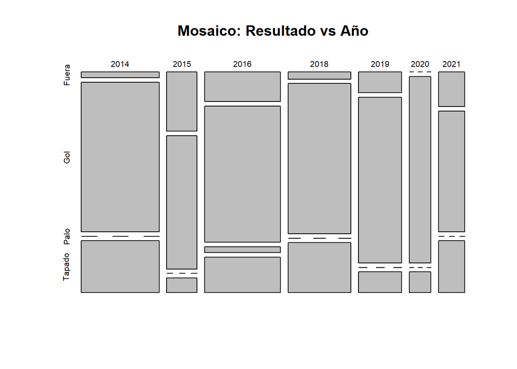

```r
mosaicplot(table(DF_A$Año_C, DF_A$Resultado_P), main="Mosaico: Resultado vs Año")
```

*Comentario:* Se puede concluir que en el año 2015 hubo mayor incidencia en tiros fuera del arco. Esto se asocia con la gráfica anterior, ya que en este año solo se celebró la Copa América y, como habíamos visto, en esta copa se suele tener mayor incidencia de tiros fuera del arco.

# Patrones

```r
cor(DF_A$Estatura_A,DF_A$Peso_A, use="complete.obs")
```

```
## [1] 0.644638
```

```r
round(cor(DF_A$Estatura_A,DF_A$Peso_A, use="complete.obs"), digits = 2)
```

```
## [1] 0.64
```

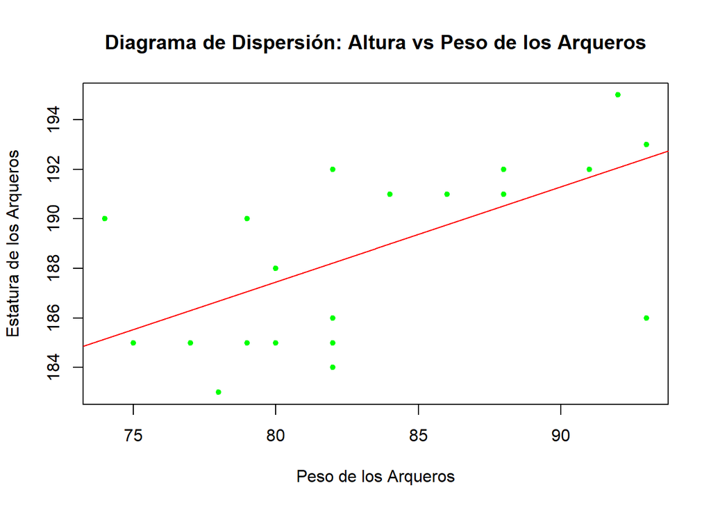

```r
plot(DF_A$Peso_A,DF_A$Estatura_A, pch=20, col="green", main="Diagrama de Dispersión: Altura vs Peso de los Arqueros",xlab = "Peso de los Arqueros", ylab = "Estatura de los Arqueros")
abline(lm(DF_A$Estatura_A ~ DF_A$Peso_A),col="red")
```

*Comentario:* La gráfica nos muestra una relación de linealidad leve, donde la esturara crece junto al peso del arquero. Esto se ve reflejado en su correlación de 0.64.Observamos una relación lineal débil, sin embargo, sigue existiendo una relación directamente proporcional.

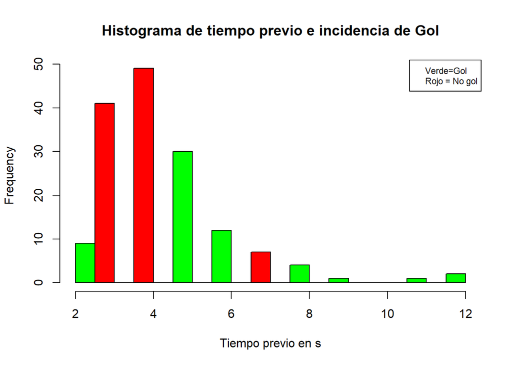

```r
leyen=c("Verde=Gol", "Rojo = No gol")
hist(DF_J$Tiempo_Prev, col = ifelse(DF_J$Resultado_P == "Gol","green", "red"), main = "Histograma de tiempo previo e incidencia de Gol", nclass = 20,xlab = "Tiempo previo en s")

legend("topright", legend = paste(leyen), cex = 0.71)
```

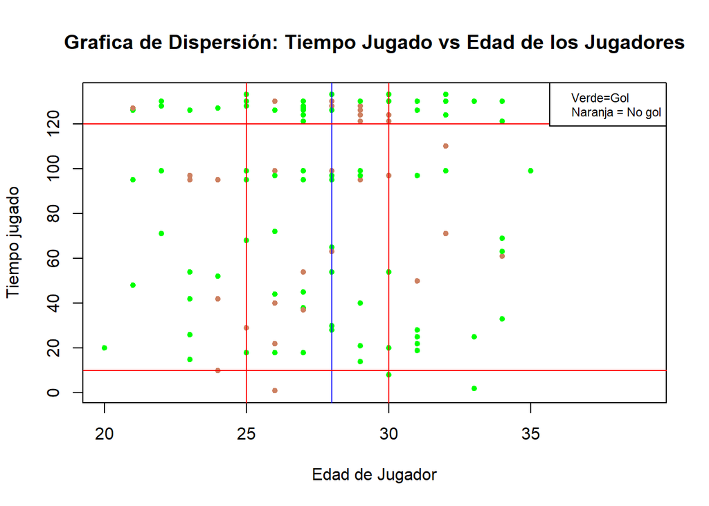

```r
leyen=c("Verde=Gol", "Naranja = No gol")
plot(main="Grafica de Dispersión: Tiempo Jugado vs Edad de los Jugadores",DF_J$Edad_J,DF_J$Tiempo_J, pch = 20, col = ifelse(DF_J$Resultado_P == "Gol","green", "lightsalmon3"),xlab = "Edad de Jugador",ylab =  "Tiempo jugado")
abline(v = 30, col = "red")
abline(v = 25, col = "red")
abline(v = 28, col = "blue")
abline(h = 120, col = "red")
abline(h = 10, col = "red")
legend("topright", legend = paste(leyen), cex = 0.71)
```

*Comentario* Se puede concluir que los jugadores entre las edades de 25 y 30 años jugaron los 120 minutos del partido en mayor proporción a las demás edades. Entre ellos, los que tienen entre 25 y 28 años tuvieron mayor efectividad en sus tiros que el resto.

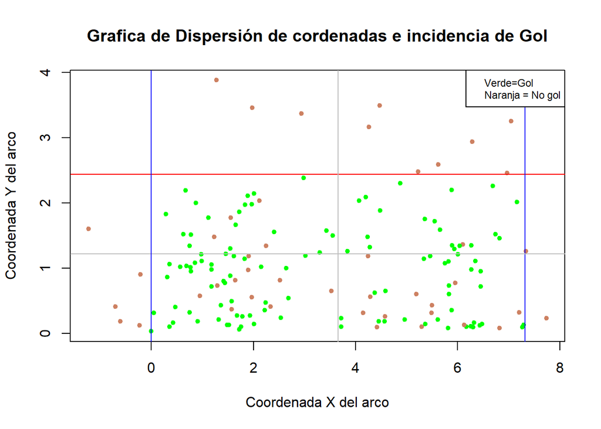

```r
leyen=c("Verde=Gol", "Naranja = No gol")
plot(DF_J$Coordenada_X, DF_J$Coordenada_Y, pch = 20, col = ifelse(DF_J$Resultado_P == "Gol","green", "lightsalmon3"), main = "Grafica de Dispersión de cordenadas e incidencia de Gol",xlab = "Coordenada X del arco", ylab = "Coordenada Y del arco")
abline(h=2.44, col = "red")
abline(v=7.32, col = "blue")
legend("topright", legend = paste(leyen), cex = 0.71)
abline(h=1.22, col ="grey")
abline(v=7.32/2, col ="grey")
abline(v=0, col ="blue")
```

```r
table(DF_A$Resultado_P)
```

```
##
##  Fuera    Gol   Palo Tapado
##     15    111      1     29
```

# Variables Aleatorias

| **Variable** | **Justificación** |
| --- | --- |
| Resultado_P | Esta variable representa si fue gol o no el tiro de penal. Es una variable aleatoria discreta y puede ser descrita como por un modelo Bernoulli-p, siendo el éxito si el tiro fue gol. X ~ Ber(111/156).… |
| Resultado_P | Reutilizamos la variable como discreta como un modelo Binomial. La variable describe como éxito el gol al haber pateado 10 veces (utilizamos este número ya que es la media de tiros de todas las rondas… |
| Pierna | Esta variable es aleatoria discreta, ya que puede representarse como 0,1 con las piernas izquierda y derecha respectivamente. Además, se representaría como una Bernoulli-p, describiendo como el éxito … |
| Resultado_Atajada | La variable es aleatoria discreta, ya que toma 156 valores. Su distribución sería geométrica, y describe la cantidad de intentos hasta que se obtiene el éxito (penal tapado), con un límite de 10 tiros… |
| Resultado_Gol | La variable es aleatoria discreta, ya que toma 156 valores. Su distribución sería geométrica, y describe la cantidad de intentos hasta que un penal sea gol. X ~ Geo(10, 111/156). Esto ayudaría en sabe… |
| Posición | La variable es aleatoria discreta. Su distribución es geométrica, y describe el número de intentos hasta que un penal sea tirado por un delantero. X ~ Geo(10, 58/156). Esto nos ayudará a saber si se p… |

```r
set.seed(156)                                  # Set seed for reproducibility
N <- 156
y_rbern <- rbern(N, prob = 111/156)                  # Draw N random values
y_rbern
```

```
##   [1] 1 1 1 1 1 1 1 1 0 1 1 1 1 0 1 1 0 0 0 1 1 0 0 1 1 1 1 1 0 0 1 1 1 1 0 1 0
##  [38] 1 1 1 0 1 1 0 0 1 0 1 1 1 1 1 1 0 0 1 1 1 0 1 1 1 1 0 1 0 1 1 1 0 1 0 1 1
##  [75] 1 1 0 0 1 1 0 1 1 0 0 1 1 1 1 1 0 1 0 1 1 0 1 1 1 1 1 1 1 0 1 1 1 1 1 1 1
## [112] 1 1 1 1 1 1 1 1 0 1 1 1 1 0 0 1 1 1 0 0 1 1 1 1 1 0 0 1 0 1 1 1 1 1 1 0 1
## [149] 0 1 0 1 1 0 0 1
```

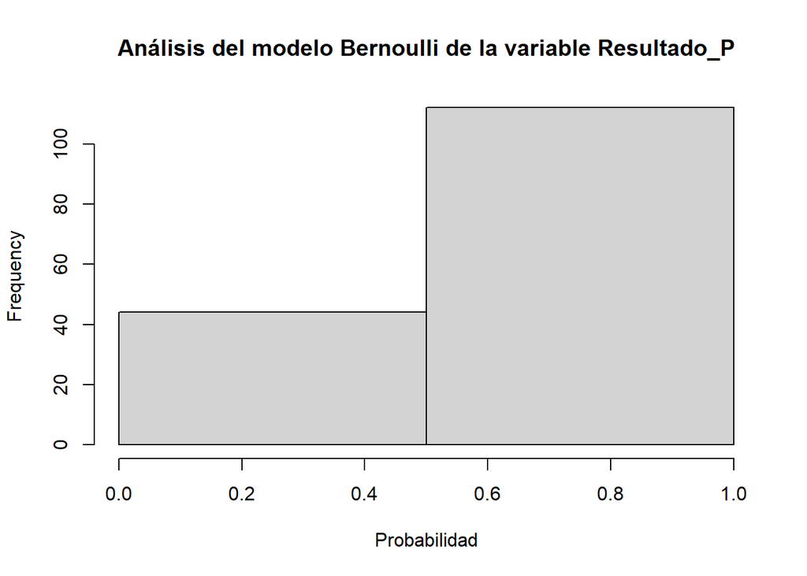

```r
hist(y_rbern,                                   # Plot of randomly drawn density
     breaks = 2
     ,main= "Análisis del modelo Bernoulli de la variable Resultado_P", xlab = "Probabilidad")
```

```r
table(DF_A$Resultado_P)
```

```
##
##  Fuera    Gol   Palo Tapado
##     15    111      1     29
```

Comentario: Como podemos ver nuestra V.A.D de tipo Bernoulli-p coincide con el éxito de nuestro experimento “Gol”, ya que nuestra variable muestra que “Gol” es la más numerosa de las cuatro variables.

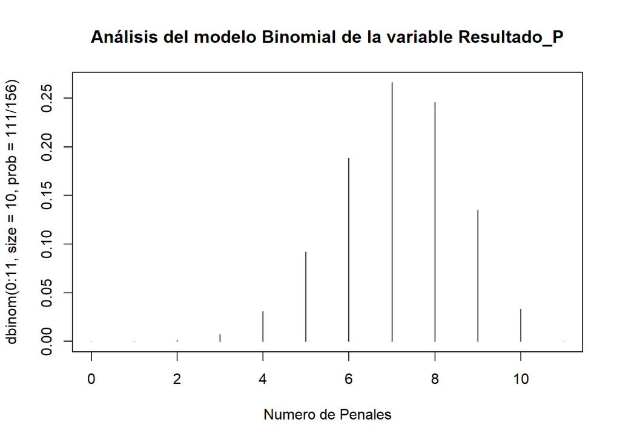

```r
plot(0:11,dbinom(0:11, size=10, prob=111/156),main= "Análisis del modelo Binomial de la variable Resultado_P",type = 'h', xlab = "Numero de Penales")
```

```r
set.seed(156)                                  # Set seed for reproducibility
N <- 156
y_rbern <- rbern(N, prob = 119/156)                  # Draw N random values
y_rbern
```

```
##   [1] 1 1 1 1 1 1 1 1 0 1 1 1 1 0 1 1 0 1 1 1 1 1 0 1 1 1 1 1 1 0 1 1 1 1 0 1 1
##  [38] 1 1 1 0 1 1 0 0 1 0 1 1 1 1 1 1 0 0 1 1 1 0 1 1 1 1 0 1 0 1 1 1 0 1 0 1 1
##  [75] 1 1 0 1 1 1 0 1 1 0 0 1 1 1 1 1 0 1 0 1 1 0 1 1 1 1 1 1 1 0 1 1 1 1 1 1 1
## [112] 1 1 1 1 1 1 1 1 0 1 1 1 1 1 0 1 1 1 1 0 1 1 1 1 1 0 0 1 0 1 1 1 1 1 1 0 1
## [149] 0 1 0 1 1 0 0 1
```

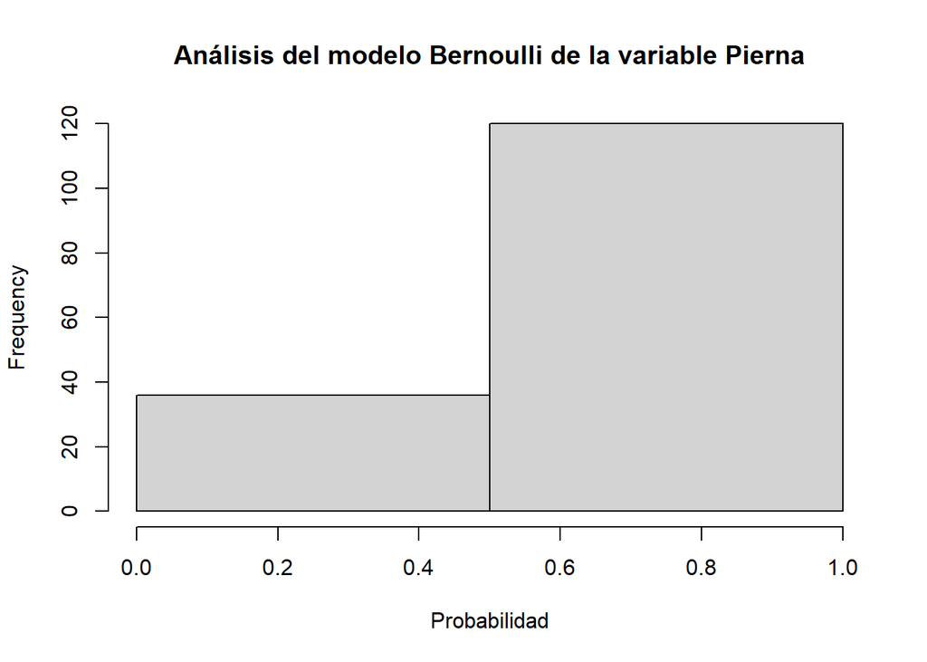

```r
hist(y_rbern,                                    # Plot of randomly drawn density
     breaks = 2,
     main = "Análisis del modelo Bernoulli de la variable Pierna",
     xlab = "Probabilidad",
     )
```

```r
table(DF_J$Pierna)
```

```
##
##   Derecha Izquierda
##       119        37
```

Comentario: Se evidencia que de todos los penales pateados en nuestro experimento, la mayoría patean con la derecha, esto se relaciona que en general hay más personas derechas que zurdas.

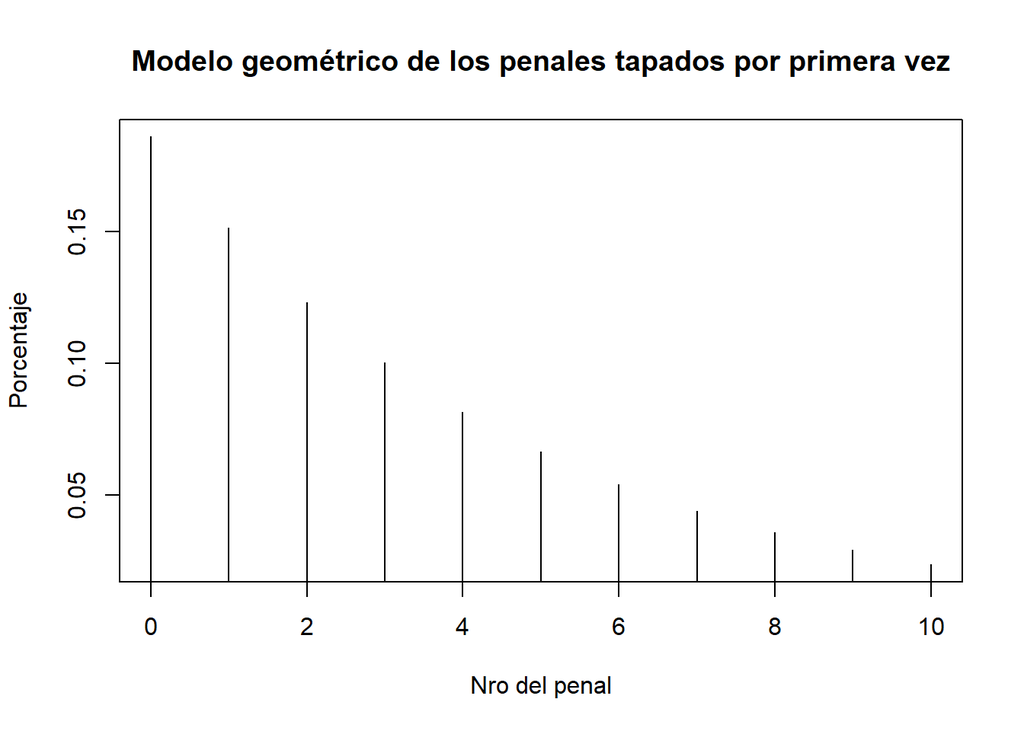

```r
plot(0:10,dgeom(0:10, prob=29/156),main= "Modelo geométrico de los penales tapados por primera vez",type = 'h',xlab = "Nro del penal", ylab = "Porcentaje")
```

Comentario: Como se puede observar en la gráfica, la tendencia de que cada tiro sea el primer penal tapado va decreciendo conforme avanza el número de penaltis. Sin embargo, dicha tendencia no sufre cambios abruptos respecto a sus anteriores.

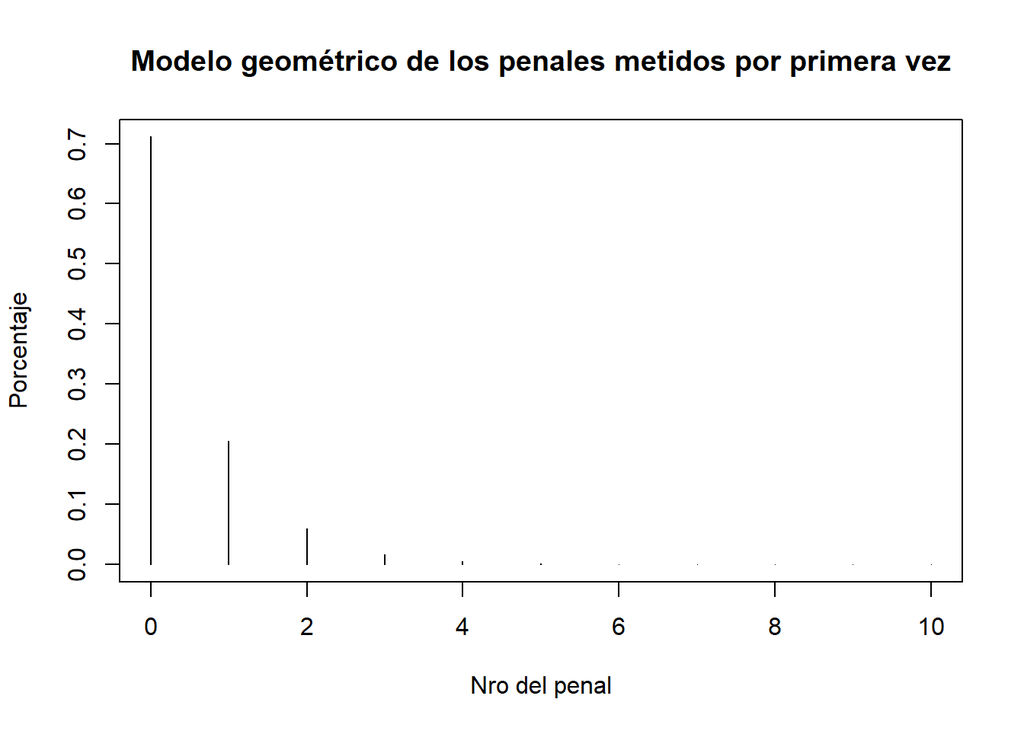

```r
plot(0:10,dgeom(0:10, prob=111/156),main= "Modelo geométrico de los penales metidos por primera vez",type = 'h',xlab = "Nro del penal", ylab = "Porcentaje")
```

Comentario: Como se puede observar en la gráfica, la probabilidad de que el primer penal haya sido anotado es alta. Además, se observa una variación abrupta de este respecto al segundo penal (casi 0.5 menos). A partir de aquí, la probabilidad de éxito es muy pequeña conforme pasan los penales, pero la diferencia entre ellos es mínima.

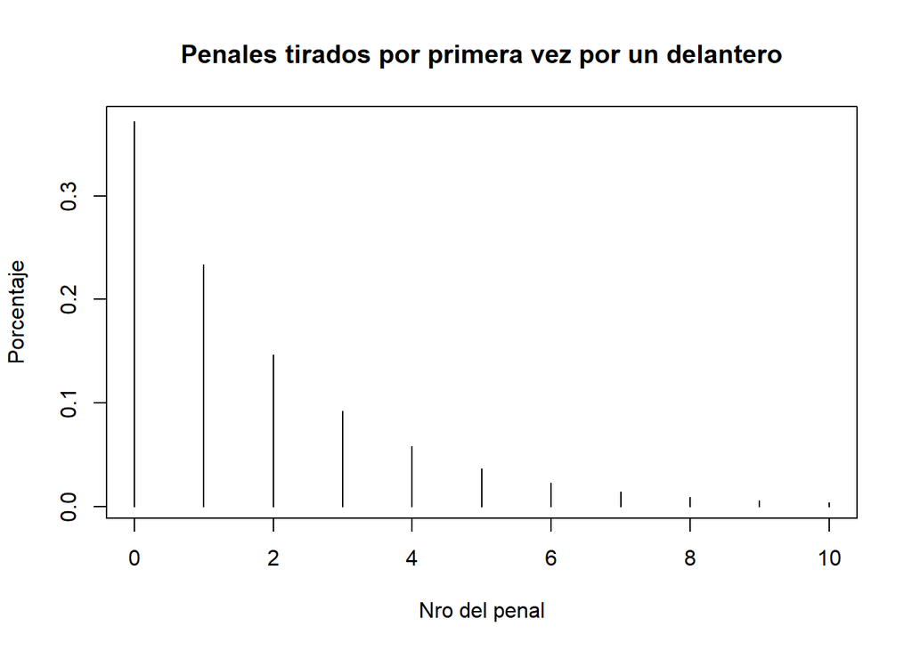

```r
plot(0:10,dgeom(0:10,58/156),type = 'h',main = "Penales tirados por primera vez por un delantero",xlab = "Nro del penal", ylab = "Porcentaje")
```

Comentario: Como se puede observar en la gráfica, el primer penal no suele ser tirado en su mayoría por un delantero. Con esto podemos concluir que existen otros jugadores en otras posiciones que pueden ser más efectivos al tirar el primer penalti (sea por práctica o por experiencia).

# Intervalos de Confianza

Proponemos intervalos de confianza de nuestras variables para usar los que más nos convenga analizar en regresiones.

## Intervalos del tiempo previo para el Gol

```r
Gols <- DF_J %>% filter(Resultado_P == "Gol")
n <- ((qnorm(0.95)^2*(sd(Gols$Tiempo_Prev)^2))/(5^2))
ceiling(n)
```

```
## [1] 1
```

Usamos un nivel de confianza del 95%, ya que la muestra mínima con dicho nivel es de 1
$$n \geq 1$$

```
##
##  One-sample z-Test
##
## data:  Summarized x
## z = 29.943, p-value < 2.2e-16
## alternative hypothesis: true mean is not equal to 0
## 95 percent confidence interval:
##  4.184400 4.770555
## sample estimates:
## mean of x
##  4.477477
```

$$[4.184400 , 4.770555]$$

## Intervalos del tiempo de juego para el gol

```r
n <- ((qnorm(0.94)^2*(sd(Gols$Tiempo_J)^2))/(6^2))
ceiling(n)
```

```
## [1] 123
```

```r
n <- ((qnorm(0.95)^2*(sd(Gols$Tiempo_J)^2))/(5^2))
ceiling(n)
```

```
## [1] 198
```

Usamos un nivel de confianza del 94%, ya que la muestra mínima con dicho nivel es de 123; a diferencia de que, si usamos un nivel de 95%, esta saldría 198, que es mayor a la que nosotros usamos en el experimento.

$$n \geq 123$$

```
##
##  One-sample z-Test
##
## data:  Summarized x
## z = 26.515, p-value < 2.2e-16
## alternative hypothesis: true mean is not equal to 0
## 94 percent confidence interval:
##  84.30234 97.17514
## sample estimates:
## mean of x
##  90.73874
```

$$[84.30234 , 97.17514]$$

## Intervalo de la coordenada horizontal para el gol

```r
n <- ((qnorm(0.95)^2*(sd(Gols$Coordenada_X)^2))/(5^2))
ceiling(n)
```

```
## [1] 1
```

Usamos un nivel de confianza del 95%, ya que la muestra mínima con dicho nivel es de 1
$$n \geq 1$$

```
##
##  One-sample z-Test
##
## data:  Summarized x
## z = 18.305, p-value < 2.2e-16
## alternative hypothesis: true mean is not equal to 0
## 95 percent confidence interval:
##  2.946934 3.653679
## sample estimates:
## mean of x
##  3.300306
```

$$[2.946934 , 3.653679]$$

## Intervalo de la estatura del jugador para el gol

```r
n <- ((qnorm(0.95)^2*(sd(Gols$Estatura_J)^2))/(5^2))
ceiling(n)
```

```
## [1] 5
```

```r
Gols <- DF_J %>% filter(Resultado_P == "Gol")


Tmean=mean(Gols$Estatura_J)
AHsd=sd(Gols$Estatura_J)
zsum.test(mean.x=Tmean,sigma.x=AHsd, n.x=156, conf.level=0.95)
```

```
##
##  One-sample z-Test
##
## data:  Summarized x
## z = 342.6, p-value < 2.2e-16
## alternative hypothesis: true mean is not equal to 0
## 95 percent confidence interval:
##  178.5851 180.6401
## sample estimates:
## mean of x
##  179.6126
```

$$[178.5851 , 180.6401]$$

# Pruebas de Hipótesis

Función para colorear el área rechazada:

```r
colorArea <- function(from, to, density, ..., col="red", dens=NULL){
y_seq <- seq(from, to, length.out=500)
d <- c(0, density(y_seq, ...), 0)
polygon(c(from, y_seq, to), d, col=col, density=dens)
}
```

## Hipótesis 1

Se eligió un nivel de confianza del 94% y una significancia del 6%.

$\tilde{x} \approx t(155)$

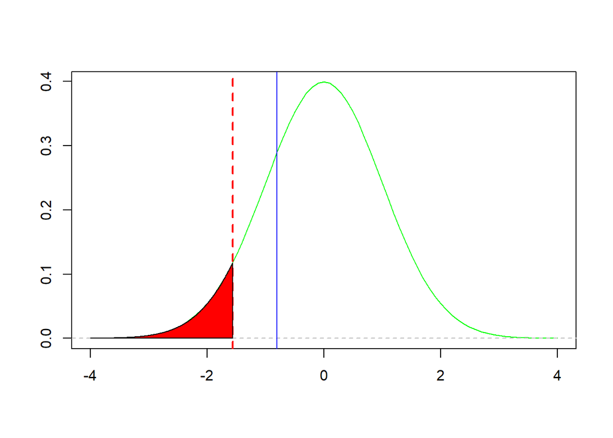

```r
tc <- qt(0.06, df = 155)
mu <- 94
n<- nrow(Gols)
s <- sd(Gols$Tiempo_J)
x <- mean(Gols$Tiempo_J)
T <- (x-mu)/(s/sqrt(n))
Xs <- seq(-4, 4, by = 0.1)
plot(Xs, dnorm(Xs), type = "l", col="green", xlab = "", ylab = "")
abline(v = tc, lty = 2, col = "red",lwd =2)
abline(h = 0, lty = 2, col = "gray")
abline(v = T,lty = 1 , col = "blue")
colorArea(from=tc, to=-4, dnorm)
```

Comentario: Podemos observar que el estadístico de prueba se encuentra por encima del punto t crítico (zona de no-rechazo). Por lo tanto, la hipótesis nula no se rechaza.

## Hipótesis 2

El tiempo previo a patear un penal de jugadores que metieron gol es de, máximo, 5 segundos.

$H_o : µ <= 5$

$H_1 : µ >5$

Se eligió un nivel de confianza del 95% y una significancia del 5%.

$\tilde{x} \approx t(155)$

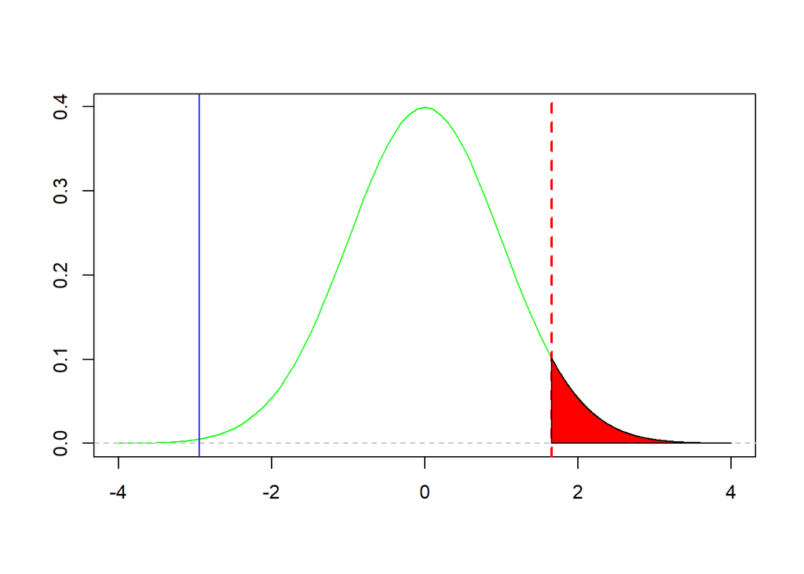

```r
pc <- qt(0.05, df =155, lower.tail = F)
mu <- 5
n<- nrow(Gols)
s <- sd(Gols$Tiempo_Prev)
x <- mean(Gols$Tiempo_Prev)
T <- (x-mu)/(s/sqrt(n))
Xs <- seq(-4, 4, by = 0.1)
plot(Xs, dnorm(Xs), type = "l", col="green", xlab = "", ylab = "")
abline(v = pc, lty = 2, col = "red",lwd =2)
abline(h = 0, lty = 2, col = "gray")
abline(v = T,lty = 1 , col = "blue")
colorArea(from=pc, to=4, dnorm)
```

Comentario: Se puede observar que el estadístico de prueba se encuentra en la zona de no-rechazo. Por lo tanto, la hipótesis nula no se rechaza.

## Hipotesis 3

Los jugadores que han metido gol miden más de 1.79.

$H_o : µ >= 1.79$

$H_1 : µ<1.79$

Se eligió un nivel de confianza del 95% y una significancia del 5%.

$\tilde{x} \approx t(155)$

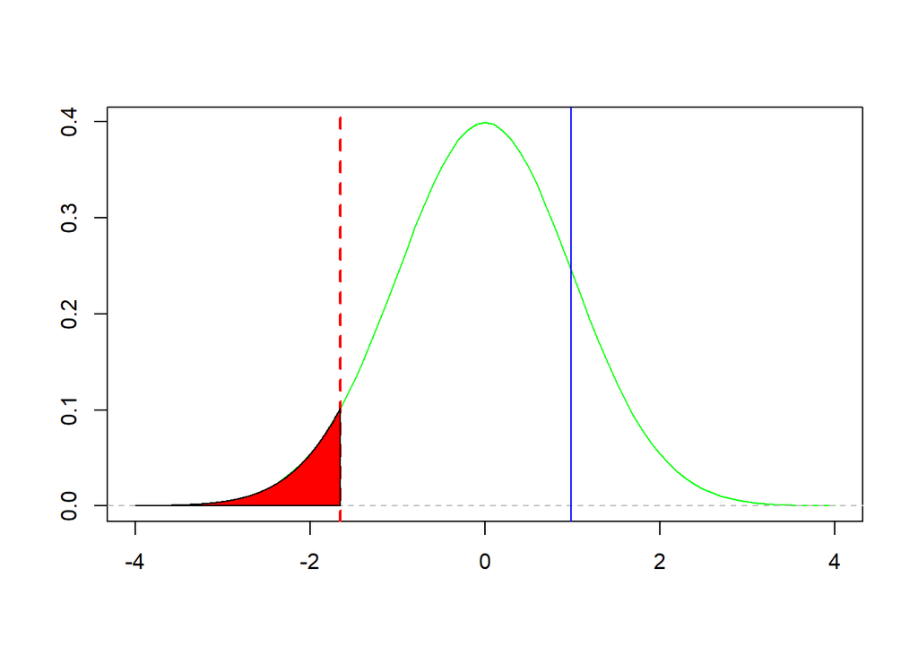

```r
tc <- qt(0.05,df = 155)
mu <- 179
n<- nrow(Gols)
s <- sd(Gols$Estatura_J)
x <- mean(Gols$Estatura_J)
T <- (x-mu)/(s/sqrt(n))
Xs <- seq(-4, 4, by = 0.1)
plot(Xs, dnorm(Xs), type = "l", col="green", xlab = "", ylab = "")
abline(v = tc, lty = 2, col = "red",lwd =2)
abline(h = 0, lty = 2, col = "gray")
abline(v = T,lty = 1 , col = "blue")
colorArea(from=-4, to=tc, dnorm)
```

Comentario: Se puede observar que el estadístico de prueba se encuentra en la zona de no-rechazo. Por lo tanto, la hipótesis nula no se rechaza.

## Hipotesis 4

Los jugadores que han metido gol han pateado en una coordenada X mayor o igual a 4.

$H_o : µ >= 4$

$H_1 : µ<4$

Se eligió un nivel de confianza del 95% y una significancia del 5%.

$\tilde{x} \approx t(155)$

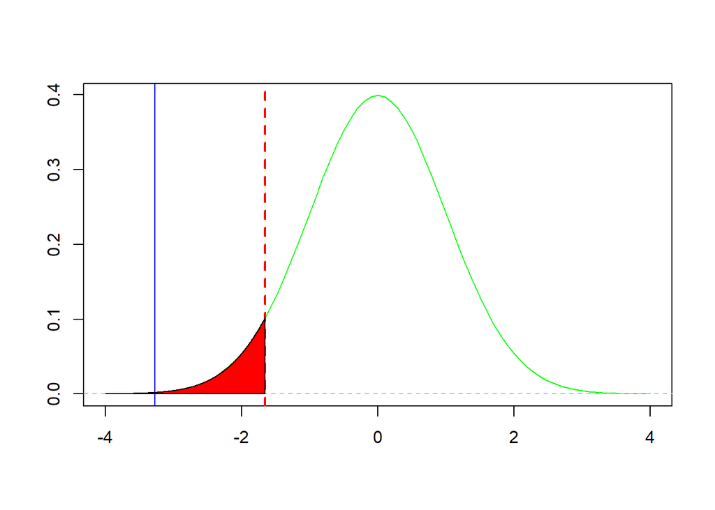

```r
tc <- qt(0.05,df = 155)
mu <- 4
n<- nrow(Gols)
s <- sd(Gols$Coordenada_X)
x <- mean(Gols$Coordenada_X)
T <- (x-mu)/(s/sqrt(n))
Xs <- seq(-4, 4, by = 0.1)
plot(Xs, dnorm(Xs), type = "l", col="green", xlab = "", ylab = "")
abline(v = tc, lty = 2, col = "red",lwd =2)
abline(h = 0, lty = 2, col = "gray")
abline(v = T,lty = 1 , col = "blue")
colorArea(from=-4, to=tc, dnorm)
```

Comentario: Podemos observar que el estadístico de prueba se encuentra en el área rechazable. Por lo tanto, la hipótesis nula es rechazada.